# Funcionalidades e outras formatações

# 1 Opções do YAML

## Tabela de conteúdos

```
# Título nível 1

## Título nível 2

### Título nível 3
```

Suponha que no índice só devam aparecer títulos de nível até 2. Para isso utilizamos `toc_depth: 2` no cabeçalho. Lembre-se que o nível do título é definido pela quatidade de `#`.

## Numeração de seções

Podemos numerar as seções facilmente, quando o outpt é um documento pdf ou html, adicionando `number_sections: true` no YAML. Com isso, todos as seções serão numeradas. Já ao escolher um documento de word como output, é necessário criar um arquivo de referência. Veja este tutorial para aprender a criar um arquivo de referência.

Para que uma seção específica não seja numerada, mesmo definindo `number_sections: true`, basta adicionar `{-}` ao lado do nome da seção:

```
## Título que será numerado

## Título que não será numerado {-}
```

**Exemplo**:

```
output:
  html_document:
    toc: true
    number_sections: true
```

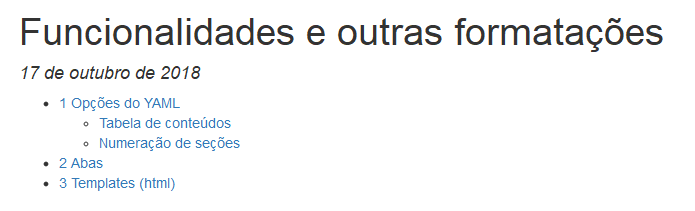

## Helps e outras opções

Para consultar possíveis argumentos colocados no YAML, basta verificar o help das funções do pacote `rmarkdown` de mesmo nome do `output`. Por exemplo, se `output: html_document`, devemos ver o help da função `html_document`, do pacote `rmarkdown`.

# 2 Abas

Para inserir abas em um documento html, basta inserir, ao lado de um título: `{.tabset}`. Em seguida inserimos subtítulos, que se tornarão abas. O conteúdo abaixo de cada subtítulo será associado à respectiva guia. Para fechar a divisão em abas inserimos um título de nível igual ao que abriu as abas.

```
## Seção {.tabset}

### Primeira aba

Conteúdo da primeira aba

### Segunda aba

Conteúdo da segunda aba

## Próxima seção

Conteúdo após a divisão em abas
```

Caso estejamos com `number_sections: true` e não queiramos criar uma próxima seção, basta inserir `## {-}`.

**Exemplo**:

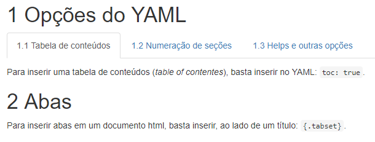

# 3 Templates (html)

- [`prettydoc`](http://yixuan.cos.name/prettydoc/)
- [`rmdformats`](https://github.com/juba/rmdformats)
- [`tufte`](https://github.com/rstudio/tufte)

Em geral esses pacotes permitem as mesmas formatações de qualquer relatório em html. No entanto, algumas funcionalidades podem não funcionar ao utilizá-los. Por exemplo, no `prettydoc` não é possível inserir abas como mostrado aqui. É importante estar atentos ao repositório desses pacotes no GitHub para relatar e verificar a existência de problemas na utilização dos pacotes.

Veja exemplos de relatórios utilizando estes pacotes:

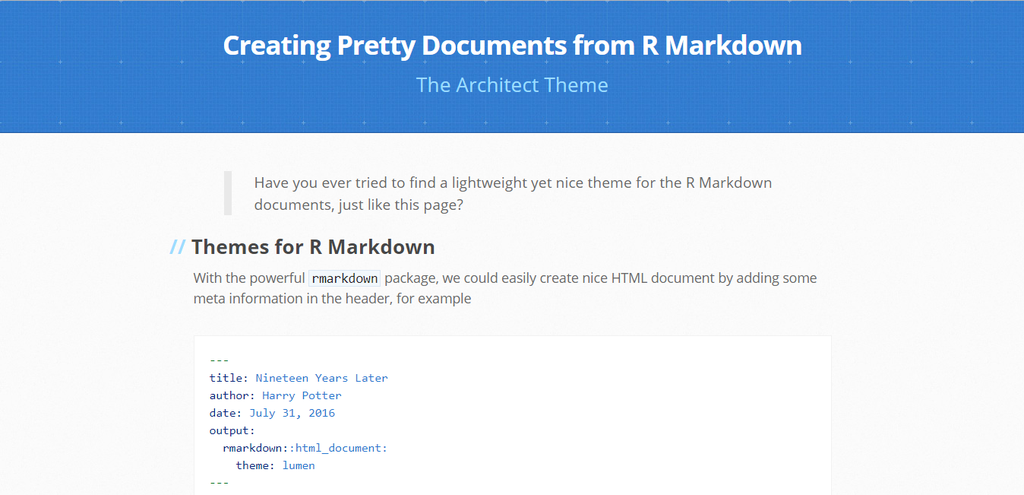

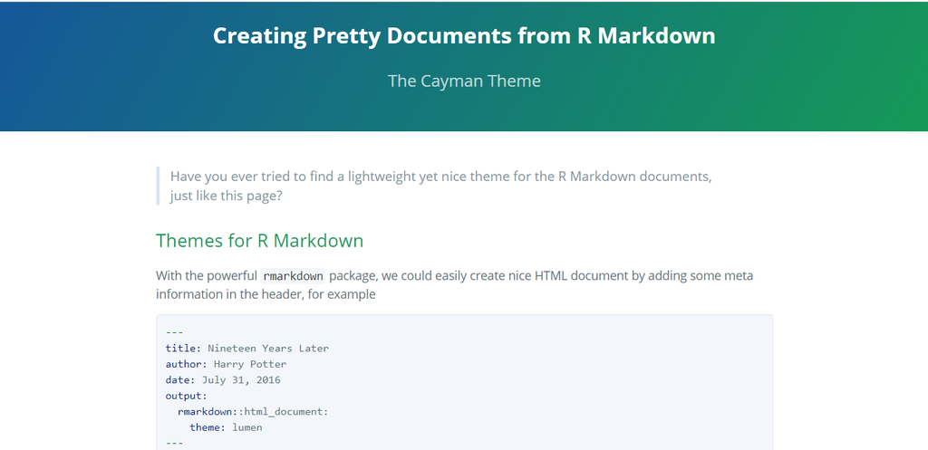

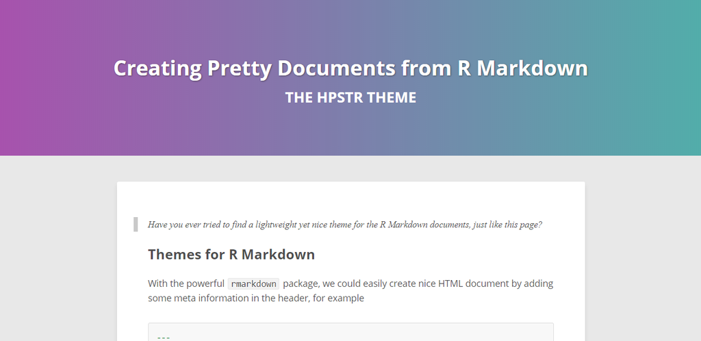

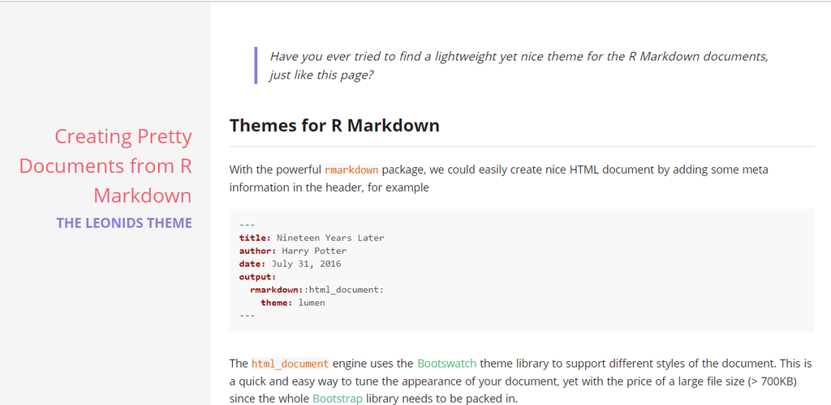

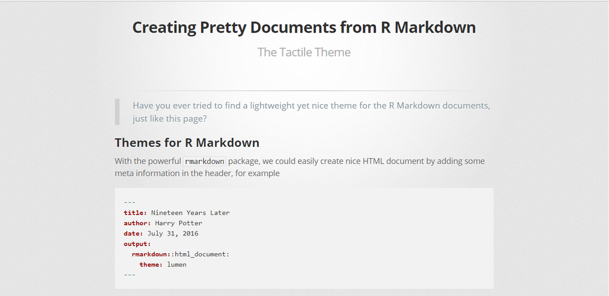

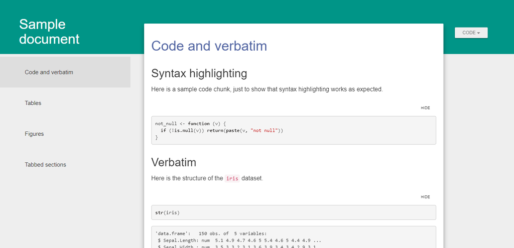

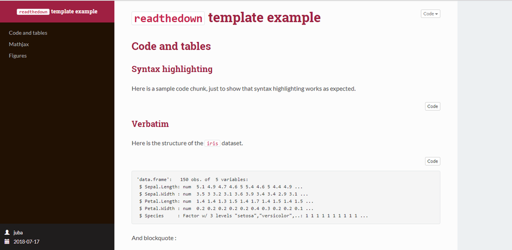

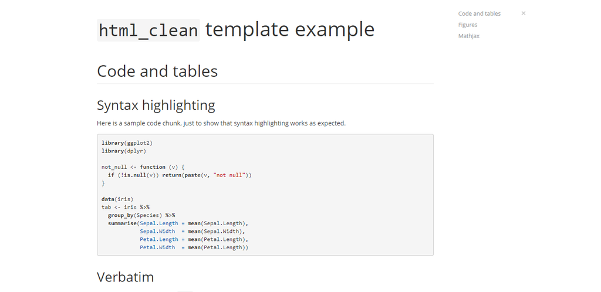

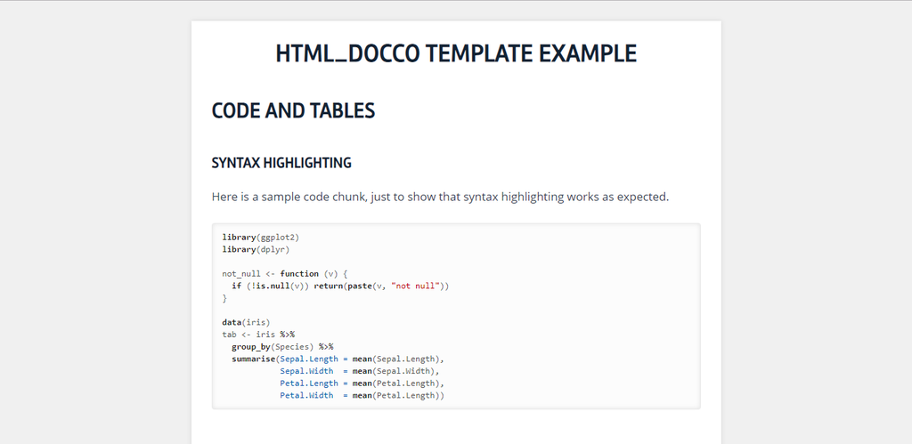

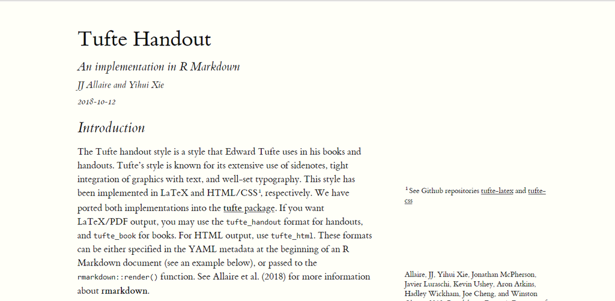

**Considerações finais**

Leonardo Filgueira e Matheus Camelo

17 de outubro de 2018